# Alternative datasets

Load packages

```r
library(SeuratData)
library(Seurat)
options(Seurat.object.assay.version = "v5")
```

#since the task for me is to use dataset1(pbmc), and there is no space in the report for brain data #but I still use codes to have a basic visulizeation

#Please find attached the dataset for assessment 3. #Please open the project in Rstudio and use dataset 1+the data set 1 (pbmc) should be obtained using the script.

# PBMC scRNA-seq

#Download dataset

```r
options(timeout=6000)
InstallData("pbmcsca")
data("pbmcsca")
pbmcsca <- UpdateSeuratObject(pbmcsca)
```

```
Validating object structure
Updating object slots
Ensuring keys are in the proper structure
警告: Assay RNA changing from Assay to Assay
Ensuring keys are in the proper structure
Ensuring feature names don't have underscores or pipes
Updating slots in RNA
Validating object structure for Assay ‘RNA’
Object representation is consistent with the most current Seurat version
```

#In the practical session we subsetted pbmcsca dataset and looked at 2 batches from 10x platforms. Here we compare more platforms.

```r
pbmcsca$Method |> table()
```

```
  10x Chromium (v2) 10x Chromium (v2) A 10x Chromium (v2) B   10x Chromium (v3)            CEL-Seq2            Drop-seq
               3362                3222                3222                3222                 526                6584
            inDrops            Seq-Well          Smart-seq2
               6584                3773                 526
```

```r
batchNames <- c(
  "10x Chromium (v3)", "CEL-Seq2", "Drop-seq", "Seq-Well", "inDrops", "Seq-Well", "Smart-seq2"
)
pbmc <- pbmcsca[,pbmcsca$Method %in% batchNames]
pbmc
```

```
An object of class Seurat
33694 features across 21215 samples within 1 assay
Active assay: RNA (33694 features, 0 variable features)
 2 layers present: counts, data
```

```r
pbmc$Method |> table()
```

```
10x Chromium (v3)          CEL-Seq2          Drop-seq           inDrops          Seq-Well        Smart-seq2
             3222               526              6584              6584              3773               526
```

```r
batchNames <- c(
  "10x Chromium (v3)", "CEL-Seq2", "Drop-seq", "Seq-Well", "inDrops", "Seq-Well", "Smart-seq2"
)
```

```r
install.packages("ggplot2")
```

```
Error in install.packages : Updating loaded packages
```

```r
library(ggplot2)
#install.packages("ggtitle")
```

#test only (since previously I want to use anchor+prediction but I think it is a manual work #So I change it into IntegratLyaer) #In the test, just have a basic look on the number of feature+count+mit

```r
# Test to determine which method can be used as the reference:
# Quality Control step: This block of code performs quality control
# checks on the single-cell RNA-seq dataset stored in the 'pbmc' object.

# Calculate the percentage of mitochondrial genes for each cell
# 'PercentageFeatureSet' function is used to compute the percentage of genes from the mitochondrial genome.
# Mitochondrial genes typically have the prefix "MT-", so the 'pattern' argument specifies this.
pbmc[["percent.mt"]] <- PercentageFeatureSet(pbmc, pattern = "^MT-")




VlnPlot(pbmc, features = c("nFeature_RNA", "nCount_RNA", "percent.mt"),
        group.by = "Method")
#  - 'nFeature_RNA': number of features (genes) detected per cell
#  - 'nCount_RNA': total number of RNA molecules detected per cell
#  - 'percent.mt': percentage of mitochondrial genes per cell
# The 'group.by' argument groups the cells by their 'Method' (batch method).

  #for a cleaner, more modern visual appearance to the plot.
  theme_minimal()
```

[output not shown]

#this is only for v3 as a reference but later it seems to be time-consuming as there are not only 1 need to be anchor and prediction #this codes are mainly from the practical part #preprocessing

```r
# Normalize it
pbmc_10x_v3 <- subset(pbmc, subset = Method == "10x Chromium (v3)")
pbmc_10x_v3 <- NormalizeData(pbmc_10x_v3)
dim(pbmc_10x_v3)  # Dimensions of the v3 dataset
# Feature Selection
pbmc_10x_v3 <- FindVariableFeatures(pbmc_10x_v3, selection.method = "vst", nfeatures = 3000)
# Scale it
pbmc_10x_v3.all.genes <- rownames(pbmc_10x_v3)
pbmc_10x_v3 <- ScaleData(pbmc_10x_v3, features = pbmc_10x_v3.all.genes)
# Do PCA
pbmc_10x_v3 <- RunPCA(pbmc_10x_v3, features = VariableFeatures(object = pbmc_10x_v3))
# Draw UMAP
pbmc_10x_v3 <- FindNeighbors(pbmc_10x_v3, dims = 1:30)
pbmc_10x_v3 <- RunUMAP(pbmc_10x_v3, dims=1:30)

DimPlot(pbmc_10x_v3, reduction = "umap", label = TRUE, group.by = 'CellType') + theme(legend.position = "none")
```

[output not shown]

#this codes are mainly from the practical part #using pbmc_combo to perform the whole analysis

```r
pbmc_combo <- subset(pbmc, Method %in% c("10x Chromium (v3)", "CEL-Seq2", "Drop-seq", "inDrops", "Seq-Well", "Smart-seq2"))
# Normalize it
pbmc_combo <- NormalizeData(pbmc_combo)
#selects genes that show high variance across cells.
pbmc_combo <- FindVariableFeatures(pbmc_combo, selection.method = "vst", nfeatures = 3000)
```

#this codes are mainly from the practical part

```r
# normalizes the data by centering and scaling the expression levels for each gene.
# remove technical noise and batch-specific variation
pbmc_combo.all.genes <- rownames(pbmc_combo)
pbmc_combo <- ScaleData(pbmc_combo, features = pbmc_combo.all.genes)
```

#this codes are mainly from the practical part

```r
# Perform Principal Component Analysis (PCA):
# reduces the dimensionality of the data by identifying major axes of variation (principal components).
pbmc_combo <- RunPCA(pbmc_combo, features = VariableFeatures(object = pbmc_combo))
```

```
PC_ 1
Positive:  CCL5, NKG7, IL7R, GNLY, GZMH, PRF1, KLRD1, FGFBP2, CD8A, GZMB
       KLRB1, CXCR4, CD8B, ABLIM1, CCR7, TRDC, GZMK, SPON2, SYTL3, LEF1
       TSC22D3, MS4A1, RP11-291B21.2, CEBPZ, IGHM, MYOM2, PLEKHF1, CD160, TIGIT, CFAP97
Negative:  LYZ, S100A9, FCN1, CST3, VCAN, S100A8, PSAP, CTSS, CD14, CD68
       GRN, SERPINA1, NCF2, CSF3R, COTL1, MPEG1, DUSP6, FOS, MS4A6A, CPVL
       SLC11A1, TKT, HCK, MNDA, TGFBI, RGS2, CTSB, PLAUR, SAT1, FPR1
PC_ 2
Positive:  EEF1A1, CD74, HLA-DRA, TXNIP, HLA-DRB1, HLA-DPB1, HLA-DPA1, IGHM, MS4A1, CTSS
       DUSP1, FOS, HLA-DMB, IGKC, HLA-DQA1, LYZ, CD79B, BANK1, CXCR4, IGHD
       NCF1, NFKBIA, SELL, IRF8, FCN1, S100A9, SWAP70, S100A8, PSAP, VCAN
Negative:  PPBP, TUBB1, SDPR, PF4, SPARC, HIST1H2AC, GNG11, CLU, MAP3K7CL, TREML1
       C6orf25, PRKAR2B, ACRBP, RGS18, PGRMC1, F13A1, MARCH2, TSC22D1, ITGA2B, HIST1H3H
       GP9, NXF3, CTTN, CMTM5, NGFRAP1, GPX1, C2orf88, RUFY1, HIST1H2BJ, GRAP2
PC_ 3
Positive:  NKG7, CCL5, GNLY, GZMH, PRF1, FGFBP2, KLRD1, GZMB, ITGB2, CD8A
       SPON2, SYTL3, KLRB1, GAPDH, TNFAIP3, HSPA5, TRDC, CD8B, FCGR3A, UBC
       ITGB1, MYOM2, IL7R, CX3CR1, ACTG1, ACTB, PLEKHF1, HLA-E, NUCB2, CD160
Negative:  MS4A1, IGHM, BANK1, IGKC, HLA-DRA, IGHD, CD74, CD79B, HLA-DQA1, HLA-DRB1
       TCL1A, FCRL1, HLA-DPA1, HLA-DPB1, MEF2C, HLA-DMB, IGHG1, ADAM28, IGLC3, SWAP70
       CD19, FCRL5, IRF8, FCRLA, CD24, JCHAIN, FCER2, KIAA0125, KIAA0226L, AFF3
PC_ 4
Positive:  LYZ, S100A9, S100A8, FCN1, VCAN, G0S2, FOS, IL1B, SLC8A1-AS1, CST3
       THBS1, SGK1, TAOK1, CD14, RGS2, CYP1B1, DUSP6, CSF3R, APOBEC3A, PSAP
       DUSP1, PLAUR, FPR1, CD36, NFKBIA, ANPEP, NAMPT, CD300E, SERPINA1, PLBD1
Negative:  CH507-513H4.3, MS4A1, HLA-E, HLA-DPA1, UBC, ACTG1, HLA-DPB1, CD79B, BANK1, TXNIP
       HLA-DQA1, FCRL3, CTD-2139B15.2, GAPDH, GOLGA4, KLRD1, IGHM, OAZ1, ANAPC5, SWAP70
       TMEM70, RP11-4B16.4, ADAM28, MMS22L, IGHA1, ZNF791, IGHG1, TAGLN2, IGKC, PRF1
PC_ 5
Positive:  NKG7, FGFBP2, GZMB, GNLY, GZMH, PRF1, KLRD1, FCGR3A, SPON2, CCL5
       MYOM2, CX3CR1, TRDC, SH2D1B, HLA-DPB1, HLA-DRB1, HLA-DPA1, CD160, ITGB2, CD74
       HLA-DRA, PLEKHF1, ACTB, HLA-DQA1, IGHM, FGR, FCRL3, PTGDS, CD79B, IGHD
Negative:  IL7R, LEF1, CCR7, LDLRAP1, ITGA6, LRRN3, DPP4, TMEM204, EPHX2, ANK3
       GPR183, UBASH3A, ABLIM1, SELL, ICOS, LGALS3BP, TNFSF8, ACTN1, EEF1A1, HIVEP2
       TNFAIP3, PLK3, GZMK, CD4, DUSP16, NGFRAP1, GPRASP1, FOS, PLEKHB1, NUCB2
```

```r
# identifies cells that are similar to each other based on the principal components (PCs) identified earlier.
pbmc_combo <- FindNeighbors(pbmc_combo, dims = 1:30)
# UMAP projects high-dimensional data into 2D or 3D space, making it easier to visualize complex relationships between cells.
# the first 30 principal components (PCs) are used to generate the UMAP projection.
pbmc_combo <- RunUMAP(pbmc_combo, dims = 1:30)
```

#this codes are mainly from the practical part

```r
# Split the RNA assay data by the 'Method'
pbmc_combo[["RNA"]] <- split(pbmc_combo[["RNA"]], f = pbmc_combo$Method)
# Normalize and scale the data:
# 'ScaleData' normalizes the data by centering and scaling the expression levels for each gene.
# remove technical noise and batch-specific variation
pbmc_combo <- ScaleData(pbmc_combo)
# 'FindVariableFeatures' selects genes that show high variance across cells.
pbmc_combo <- FindVariableFeatures(pbmc_combo)
```

[output not shown]

```r
# Perform Principal Component Analysis (PCA):
# 'RunPCA' reduces the dimensionality of the data by identifying major axes of variation (principal components).
pbmc_combo <- RunPCA(pbmc_combo)
```

```
PrepDR5(object = object, features = features, layer = layer, 里有警告:
  The following features were not available: IGLC2, CDKN1C, RP11-1143G9.4, LST1, AL928768.3, NRGN, MAFB, ENAM, MS4A7, NEAT1, CLEC9A, STMN1, HLA-DQB1, S100A12, CCL2, PTGS2, AIF1, KRT1, EGR1, TUBB, C1QA, CXCL2, IGLV3-19, FTH1, CENPF, DERL3, CD79A, CCL3, CXCL8, LYPD2, IER3, LILRB2, FGL2, EREG, GATA2, B…
PC_ 1
Positive:  CCL5, NKG7, IL7R, GNLY, GZMH, PRF1, KLRD1, FGFBP2, CD8A, GZMB
       KLRB1, CD8B, CXCR4, TRDC, SPON2, GZMK, CCR7, SYTL3, LEF1, TSC22D3
       RP11-291B21.2, MYOM2, CD160, MS4A1, TIGIT, IGHM, PATL2, CREM, NUCB2, TNFAIP3
Negative:  LYZ, S100A9, FCN1, CST3, VCAN, S100A8, PSAP, CTSS, CD14, CD68
       GRN, SERPINA1, NCF2, CSF3R, COTL1, MPEG1, DUSP6, FOS, MS4A6A, CPVL
       SLC11A1, TKT, MNDA, HCK, TGFBI, RGS2, CTSB, PLAUR, DUSP1, FPR1
PC_ 2
Positive:  PPBP, TUBB1, SDPR, PF4, SPARC, HIST1H2AC, GNG11, CLU, MAP3K7CL, TREML1
       C6orf25, PRKAR2B, ACRBP, RGS18, PGRMC1, F13A1, MARCH2, TSC22D1, ITGA2B, GP9
       HIST1H3H, CTTN, NXF3, CMTM5, GPX1, NGFRAP1, C2orf88, RUFY1, GRAP2, CD9
Negative:  CD74, HLA-DRA, HLA-DRB1, HLA-DPB1, HLA-DPA1, IGHM, MS4A1, CTSS, DUSP1, IGKC
       FOS, LYZ, HLA-DMB, IGHD, HLA-DQA1, BANK1, CD79B, NFKBIA, NCF1, CXCR4
       S100A9, S100A8, FCN1, SELL, SWAP70, IRF8, VCAN, TCL1A, PSAP, MEF2C
PC_ 3
Positive:  NKG7, CCL5, GNLY, GZMH, FGFBP2, PRF1, KLRD1, GZMB, CD8A, TNFAIP3
       KLRB1, SYTL3, SPON2, CD8B, TRDC, FCGR3A, GAPDH, IL7R, ITGB1, MYOM2
       NUCB2, CX3CR1, S100A9, ACTB, CD160, IFITM3, S100A8, GZMK, SH2D1B, IL18RAP
Negative:  MS4A1, IGHM, BANK1, IGKC, HLA-DRA, CD79B, IGHD, CD74, HLA-DQA1, HLA-DRB1
       HLA-DPA1, HLA-DPB1, TCL1A, FCRL1, MEF2C, IGHG1, HLA-DMB, ADAM28, SWAP70, IGLC3
       CD19, FCRL5, IRF8, FCRLA, CD24, JCHAIN, FCER2, KIAA0125, KIAA0226L, AFF3
PC_ 4
Positive:  IL7R, LEF1, CCR7, S100A9, S100A8, LYZ, LRRN3, FOS, VCAN, FCN1
       G0S2, IL1B, EPHX2, THBS1, SGK1, DPP4, LDLRAP1, NGFRAP1, PF4, ICOS
       GPR183, SDPR, PPBP, GNG11, CD14, CYP1B1, MAP3K7CL, SPARC, SLC40A1, TUBB1
Negative:  NKG7, FGFBP2, PRF1, KLRD1, GZMB, GNLY, GZMH, SPON2, FCGR3A, MYOM2
       CCL5, CX3CR1, TRDC, ACTG1, SH2D1B, CD160, GAPDH, ACTB, HLA-DPA1, HLA-DPB1
       KLRB1, SYTL3, CD8A, FCRL3, FGR, OAZ1, ITGB1, IL18RAP, PATL2, ANXA2
PC_ 5
Positive:  IL7R, LEF1, CXCR4, CCR7, GZMK, GPR183, TNFAIP3, LDLRAP1, DPP4, NUCB2
       ANK3, SELL, TMEM70, TSC22D3, CREM, CD84, GOLGA4, GAPDH, ACTG1, EPHX2
       CCR6, LRRN3, ICOS, RBM43, PTDSS1, TLDC1, ESF1, SESN1, TTN, SLC4A10
Negative:  GZMB, GNLY, FGFBP2, FCGR3A, NKG7, LYZ, GZMH, SPON2, PRF1, CX3CR1
       MYOM2, HLA-DRB1, KLRD1, SH2D1B, CD74, S100A9, IGHD, IGHM, FCN1, NCAM1
       PF4, TCL1A, HLA-DRA, SDPR, GNG11, CST3, PPBP, SPARC, PSAP, CCL5
```

#this codes are mainly from the practical part

```r
#plot
DimPlot(pbmc_combo, reduction = "umap", label = TRUE, group.by = 'Method')
DimPlot(pbmc_combo, reduction = "umap", label = TRUE, group.by = 'CellType')
```

[output not shown]

#save image

```r
ggsave(filename = paste0("UMAP for pbmc before batch effect correction.png"), plot = DimPlot(pbmc_combo, reduction = "umap", label = TRUE, group.by = 'Method'), width = 10, height = 8)
ggsave(filename = paste0("UMAP for pbmc cell type before batch effect correction.png"), plot = DimPlot(pbmc_combo, reduction = "umap", label = TRUE, group.by = 'CellType'), width = 10, height = 8)
```

#BE correction #this codes are mainly from the practical part #unlike the method above, IntegrateLayers will determine all things without mannually selecting a reference #this is also from the pratical part

```r
# Integrate multiple data layers (e.g., batches or conditions) using the Canonical Correlation Analysis (CCA) method.


# The 'IntegrateLayers' function integrates data from different layers (or batches).

pbmc_combo <- IntegrateLayers(


  object = pbmc_combo,

  # CCAIntegration - Canonical Correlation Analysis (CCA),
  # align and integrate different datasets by finding shared features.
  method = CCAIntegration,


  orig.reduction = "pca",


  new.reduction = "CCA"
)
```

```
Finding all pairwise anchors
```

```
  |                                                  | 0 % ~calculating
```

```
Running CCA
Merging objects
Finding neighborhoods
Finding anchors
    Found 1613 anchors
```

```
  |++++                                              | 7 % ~25s
```

```
Running CCA
Merging objects
Finding neighborhoods
Finding anchors
    Found 2323 anchors
```

```
  |+++++++                                           | 13% ~34s
```

```
Running CCA
Merging objects
Finding neighborhoods
Finding anchors
    Found 2170 anchors
```

```
  |++++++++++                                        | 20% ~35s
```

```
Running CCA
Merging objects
Finding neighborhoods
Finding anchors
    Found 2336 anchors
```

```
  |++++++++++++++                                    | 27% ~40s
```

```
Running CCA
Merging objects
Finding neighborhoods
Finding anchors
    Found 2403 anchors
```

```
  |+++++++++++++++++                                 | 33% ~41s
```

```
Running CCA
Merging objects
Finding neighborhoods
Finding anchors
    Found 8102 anchors
```

```
  |++++++++++++++++++++                              | 40% ~01m 01s
```

```
Running CCA
Merging objects
Finding neighborhoods
Finding anchors
    Found 2331 anchors
```

```
  |++++++++++++++++++++++++                          | 47% ~50s
```

```
Running CCA
Merging objects
Finding neighborhoods
Finding anchors
    Found 2329 anchors
```

```
  |+++++++++++++++++++++++++++                       | 53% ~42s
```

```
Running CCA
Merging objects
Finding neighborhoods
Finding anchors
    Found 6766 anchors
```

```
  |++++++++++++++++++++++++++++++                    | 60% ~40s
```

```
Running CCA
Merging objects
Finding neighborhoods
Finding anchors
    Found 8916 anchors
```

```
  |++++++++++++++++++++++++++++++++++                | 67% ~42s
```

```
Running CCA
Merging objects
Finding neighborhoods
Finding anchors
    Found 2458 anchors
```

```
  |+++++++++++++++++++++++++++++++++++++             | 73% ~32s
```

```
Running CCA
Merging objects
Finding neighborhoods
Finding anchors
    Found 2412 anchors
```

```
  |++++++++++++++++++++++++++++++++++++++++          | 80% ~24s
```

```
Running CCA
Merging objects
Finding neighborhoods
Finding anchors
    Found 7291 anchors
```

```
  |++++++++++++++++++++++++++++++++++++++++++++      | 87% ~18s
```

```
Running CCA
Merging objects
Finding neighborhoods
Finding anchors
    Found 11129 anchors
```

```
  |+++++++++++++++++++++++++++++++++++++++++++++++   | 93% ~11s
```

```
Running CCA
Merging objects
Finding neighborhoods
Finding anchors
    Found 9642 anchors
```

```
  |++++++++++++++++++++++++++++++++++++++++++++++++++| 100% elapsed=02m 57s
```

```
Merging dataset 1 into 6
Extracting anchors for merged samples
Finding integration vectors
Finding integration vector weights
Integrating data
Merging dataset 2 into 4
Extracting anchors for merged samples
Finding integration vectors
Finding integration vector weights
Integrating data
Merging dataset 5 into 6 1
Extracting anchors for merged samples
Finding integration vectors
Finding integration vector weights
Integrating data
Merging dataset 3 into 4 2
Extracting anchors for merged samples
Finding integration vectors
Finding integration vector weights
Integrating data
Merging dataset 4 2 3 into 6 1 5
Extracting anchors for merged samples
Finding integration vectors
Finding integration vector weights
Integrating data
```

#this codes are mainly from the practical part #after correction

```r
# re-join layers after integration
pbmc_combo[["RNA"]] <- JoinLayers(pbmc_combo[["RNA"]])

pbmc_combo <- FindNeighbors(pbmc_combo, dims = 1:30, reduction = "CCA")
pbmc_combo <- RunUMAP(pbmc_combo, dims=1:30, reduction = "CCA")
```

```
Using method 'umap'
```

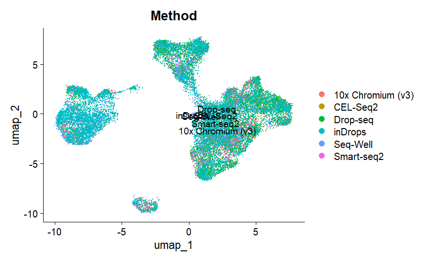

```r
DimPlot(pbmc_combo, reduction = "umap", label = TRUE, group.by = 'Method')
```

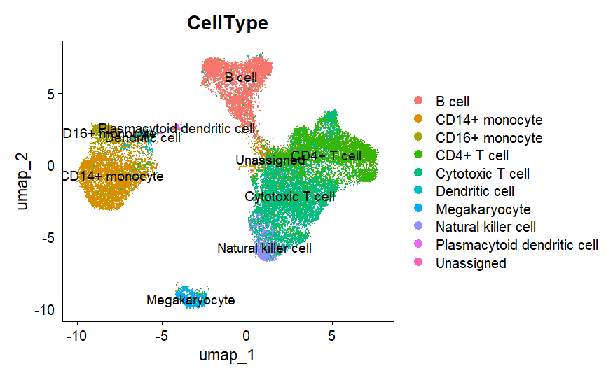

```r
DimPlot(pbmc_combo, reduction = "umap", label = TRUE, group.by = 'CellType')
```

#save images

```r
ggsave(filename = paste0("UMAP for pbmc after batch effect correction.png"), plot = DimPlot(pbmc_combo, reduction = "umap", label = TRUE, group.by = 'Method'), width = 10, height = 8)
ggsave(filename = paste0("UMAP for pbmc cell type after batch effect correction.png"), plot = DimPlot(pbmc_combo, reduction = "umap", label = TRUE, group.by = 'CellType'), width = 10, height = 8)
```

#further analysis after using the codes from the pratical section above

#evaluate BE correction

```r
library(cluster)
```

#silhouette -1 bad #0 middle #1 perfect

```r
# Access the reduced representations of single-cell data
embeddings <- Embeddings(pbmc_combo, reduction = "umap") #use umap this time
```

```
错误于Embeddings(pbmc_combo, reduction = "umap"):
  没有"Embeddings"这个函数
```

#optional: kEBT

```r
library(devtools)
install_github('theislab/kBET')
```

```
Skipping install of 'kBET' from a github remote, the SHA1 (afc5f431) has not changed since last install.
  Use `force = TRUE` to force installation
```

```r
library(kBET)
```

```r
# Get the expression matrix
expression_data <- as.data.frame(GetAssayData(pbmc_combo, assay = "RNA", slot = "data"))
```

```r
# Get the batch labels from metadata
batch_labels_method <- pbmc_combo$Method

# Get the batch labels from metadata
batch_labels_celltype <- pbmc_combo$CellType
```

```r
dim(expression_data)  # Should return something like (number of genes x number of cells)
```

```
[1] 33694 21215
```

```r
# Run kBET
kbet_results <- kBET(
  df = expression_data,
  batch = batch_labels_method,
  k0 = 10,  # Number of neighbors to consider
  do.pca = TRUE,  # Perform PCA before kBET
  dim.pca = 50,  # Number of PCA dimensions to keep
  n_repeat = 100,  # Number of bootstrap samples
  alpha = 0.05,  # P-value threshold
  plot = TRUE  # Generate plots
)
```

```
错误: 无法分配大小为10.1 Gb的向量
```

```r
# Run kBET
kbet_results <- kBET(
  df = expression_data,
  batch = batch_labels_celltype,
  k0 = 10,  # Number of neighbors to consider
  do.pca = TRUE,  # Perform PCA before kBET
  dim.pca = 50,  # Number of PCA dimensions to keep
  n_repeat = 100,  # Number of bootstrap samples
  alpha = 0.05,  # P-value threshold
  plot = TRUE  # Generate plots
)
```

[output not shown]

#and this part is for a global landscape to see the heatmap in 3.1

```r
cell_types <- unique(pbmc_combo$CellType)

# Create an empty list to store markers
cell_type_markers <- list()

#find+store and rank markers
for (cell_type in cell_types) {

  # find the markers for the current cell type
  markers <- FindMarkers(pbmc_combo, ident.1 = cell_type)

  #Sort markers by log fold change
  ranked_markers <- markers[order(markers$avg_log2FC, decreasing = TRUE), ]

  # store the top markers
  cell_type_markers[[cell_type]] <- rownames(ranked_markers)[1:10]  # Top 10 markers

  # Print or inspect the top markers for each cell type
  print(paste("Top markers for", cell_type, ":", paste(cell_type_markers[[cell_type]], collapse = ", ")))
}

#save them
all_markers <- unique(unlist(cell_type_markers))
```

```r
DoHeatmap(pbmc_combo, features = all_markers, size = 2) +  # 'size' controls the text size
  scale_fill_viridis_c() +                                 # Add  color scale
  theme(axis.text.x = element_text(size = 10, angle = 45, hjust = 1),  # X-axis text size and angle
        axis.text.y = element_text(size = 4),                      # Y-axis text size
        plot.title = element_text(size = 16))                      # Title text size
        #plot.margin = margin(5, 5, 5, 5, "cm")                     # map size
```

[output not shown]

```r
#getwd()
# Adjust the overall size when saving the plot
Savage("heatmap.png", width = 10, height = 8, dpi = 300)  # Save a bigger heatmap with high resolution
```

#creat subset for heterogeneity

```r
# Subset data for specific cell types
b_cells <- subset(pbmc_combo, subset = CellType == "B cell")
#cd14_monocytes <- subset(pbmc_combo, subset = CellType == "CD14+ monocyte")
#cd16_monocytes <- subset(pbmc_combo, subset = CellType == "CD16+ monocyte")
cd4_t_cells <- subset(pbmc_combo, subset = CellType == "CD4+ T cell")
#nk_cells <- subset(pbmc_combo, subset = CellType == "Natural killer cell")
#dendritic_cells <- subset(pbmc_combo, subset = CellType == "Dendritic cell")
toxic_t_cells <- subset(pbmc_combo, subset = CellType == "Cytotoxic T cell")
#plasmacytoid_dendritic_cells <- subset(pbmc_combo, subset = CellType == "Plasmacytoid dendritic cell")
#megakaryocytes <- subset(pbmc_combo, subset = CellType == "Megakaryocyte")
#unassigned <- subset(pbmc_combo, subset = CellType == "Unassigned")
```

#feature plot for result 3.1

```r
#CD4+CCR7 CD4T
#CD8AB toxic T
#CD18 B
#CD14 cd14mono
FeaturePlot(pbmc_combo, features = c("CD4", "CCR7", "CD8A", "CD8B", "CD19", "CD14"))
```

[output not shown]

```r
ggsave(filename = paste0("FeaturePlot for targets.png"), plot = FeaturePlot(pbmc_combo, features = c("CD4", "CCR7", "CD8A", "CD8B", "CD19", "CD14")), width = 10, height = 8)
```

#This is for 3.2 heterogeneity analysis

# know the subset umap

```r
# Normalize the data
cd4_t_cells <- NormalizeData(cd4_t_cells)

#identify variable features
cd4_t_cells <- FindVariableFeatures(cd4_t_cells)

#scale the data
cd4_t_cells <- ScaleData(cd4_t_cells)

#PCA for dimensional reduction
cd4_t_cells <- RunPCA(cd4_t_cells)

# run UMAP
cd4_t_cells <- RunUMAP(cd4_t_cells, dims = 1:10)

cd4_t_cells <- FindNeighbors(cd4_t_cells, dims = 1:10)
cd4_t_cells <- FindClusters(cd4_t_cells, resolution = 0.5)  # 0.5 this time

DimPlot(cd4_t_cells, reduction = "umap", label = TRUE, group.by = 'seurat_clusters') +
  ggtitle("UMAP of CD4+ T Cells Subset")
```

[output not shown]

```r
ggsave(filename = paste0("UMAP for CD4 subcluster.png"), plot = DimPlot(cd4_t_cells, reduction = "umap", label = TRUE, group.by = 'seurat_clusters') +
  ggtitle("UMAP of CD4+ T Cells Subset"), width = 10, height = 8)
```

#for using pipline %>%

```r
library(dplyr)
```

#find top10 gene to know different functions in each cluster in each cell type

```r
# Find markers
cd4_t_cells_markers <- FindAllMarkers(cd4_t_cells, only.pos = TRUE, min.pct = 0.25, logfc.threshold = 0.25)

#top 10 markers
top_cd4_t_cells_markers <- cd4_t_cells_markers %>%
    group_by(cluster) %>%
    top_n(n = 10, wt = avg_log2FC)

# View top markers
#print(top_b_cell_markers)
```

```r
# scanning each cultser for a look
markers_cluster <- cd4_t_cells_markers %>% filter(cluster == "3")  # Change the cluster number as needed
print(markers_cluster)
```

#This is record of the highly expressed genes/markers #we hope to find a gene will only express in a cluster to find its unique function

```r
# Identify markers
cd4_t_cells_markers <- FindAllMarkers(cd4_t_cells, only.pos = TRUE, min.pct = 0.25, logfc.threshold = 0.25)

# Get top 10 markers
top_cd4_t_cells_markers <- cd4_t_cells_markers %>%
    group_by(cluster) %>%
    top_n(n = 10, wt = avg_log2FC) %>%
    ungroup()  # Ensure the grouping does not persist

# generate FeaturePlots for top markers in each group
for (cluster in unique(top_cd4_t_cells_markers$cluster)) {

  # Filter for the top markers of the current cluster
  markers_cluster <- top_cd4_t_cells_markers %>%
    filter(cluster == !!cluster)  # Ensure correct variable scoping with '!!'

  # Only get unique top markers
  unique_markers <- unique(markers_cluster$gene)
  # Check if we have more than 10 unique markers
  if (length(unique_markers) > 10) {
    unique_markers <- unique_markers[1:10]  # Take only the first 10
  }


  # Generate FeaturePlots for each top marker
  for (marker in unique_markers) {
    p <- FeaturePlot(cd4_t_cells, features = marker,
                     pt.size = 1,
                     cols = c("lightgrey", "blue"))

    # Add title with gene and cluster information
    p <- p + ggtitle(paste("Feature Plot for", marker, "in Cluster", cluster))
    # Print the plot
    print(p)
    # Uncomment below to save the plots as images
    # ggsave(paste0("FeaturePlot_", marker, "_Cluster_", cluster, ".png"), plot = p)
  }
}
```

#improve: #setting a whole function for use from subset umap to potential unique markers

```r
# Define the function
analyze_cells <- function(seurat_object) {
  # Normalize the data
  seurat_object <- NormalizeData(seurat_object)

  # Identify variable features
  seurat_object <- FindVariableFeatures(seurat_object)

  # Scale the data
  seurat_object <- ScaleData(seurat_object)

  # Perform PCA for dimensional reduction
  seurat_object <- RunPCA(seurat_object)

  # Run UMAP
  seurat_object <- RunUMAP(seurat_object, dims = 1:10)

  # Find neighbors and clusters
  seurat_object <- FindNeighbors(seurat_object, dims = 1:10)
  seurat_object <- FindClusters(seurat_object, resolution = 0.5)  # Default resolution

  # Extract the unique cell type from the metadata
  cell_type <- unique(seurat_object$CellType)
  cell_type <- paste(cell_type, collapse = ", ")  # Concatenate if there are multiple types

  #subset UMAP visualization
  #umap_plot <- DimPlot(seurat_object, reduction = "umap", label = TRUE, group.by = 'seurat_clusters') +
  #  ggtitle(paste("UMAP of", cell_type, "Subsets"))
  #ggsave(paste0(cell_type, "subcluster.png"), plot = umap_plot)

  #print(umap_plot)  # Print the UMAP plot

  # Identify markers
  t_cells_markers <- FindAllMarkers(seurat_object, only.pos = TRUE, min.pct = 0.25, logfc.threshold = 0.25)

  # Get top 10 markers for each cluster
  top_t_cells_markers <- t_cells_markers %>%
    group_by(cluster) %>%
    top_n(n = 10, wt = avg_log2FC) %>%
    ungroup()  # Ensure the grouping does not persist

  # Loop through each cluster to generate FeaturePlots for top markers
  for (cluster in unique(top_t_cells_markers$cluster)) {
    # Filter for the top markers of the current cluster
    markers_cluster <- top_t_cells_markers %>%
      filter(cluster == !!cluster)  # Ensure correct variable scoping with '!!'

    # Only get unique top markers
    unique_markers <- unique(markers_cluster$gene)

    # Generate FeaturePlots for each top marker
    for (marker in unique_markers) {
      p <- FeaturePlot(seurat_object, features = marker,
                       pt.size = 1,  # Adjust point size as needed
                       cols = c("lightgrey", "blue"))  # Change color palette as needed

      # Add title
      p <- p + ggtitle(paste(marker))

      # Print the plot
      #print(p)

      ggsave(paste0(marker, ".png"), plot = p)
    }
  }

  # Return a summary of results
  #summary_results <- list(
  #  UMAP_Plot = umap_plot,
  #  Top_Markers = top_t_cells_markers
  #return(summary_results)  # Return summary results
}
```

```r
toxic_t_cells <- subset(pbmc_combo, subset = CellType == "Cytotoxic T cell")
results <- analyze_cells(toxic_t_cells)
```

#save

```r
#B
ggsave(filename = paste0("FeaturePlot for B subclusters.png"), plot = FeaturePlot(b_cells, features = c("SLC25A37", "FAM81B", "PRKAA2","RPL36A", "JUND", "KLF6", "NFKBID", "SLC26A4" )), width = 20, height = 16)
```

```r
#CD4
ggsave(filename = paste0("FeaturePlot for CD4 subclusters.png"), plot = FeaturePlot(cd4_t_cells, features = c("PRKAA2", "GOLGA6A", "NRDE2","JUND", "GRASP", "CST7", "APBA2", "PPIAL4A", "OPHN1" )), width = 20, height = 16)
```

```r
#CD8
ggsave(filename = paste0("FeaturePlot for Cytotoxic T subclusters.png"), plot = FeaturePlot(toxic_t_cells, features ="PRKAA2" ), width = 10, height = 8)d

#c("PRKAA2" "JUND", "GZMM","GOLGA6A", "NRDE2", "OPHN1", "FAM180B")
```

```r
una_markers <- FindMarkers(pbmc_combo, ident.1 = "Unassigned", min.pct = 0.25)
una_ranked_markers <- una_markers[order(una_markers$avg_log2FC, decreasing = TRUE), ]
print(una_ranked_markers)

una_cell_type_markers <- rownames(una_ranked_markers)[1:10]  # Top 10 markers

print(paste("Top markers for UNA:", paste(una_cell_type_markers, collapse = ", ")))
```

#This part is to generate each cell type UMAP and heatmap of high expression genes which has been mentioned and treated as limited use #since highly express gene is not equal to makers, not unique finctions #only success before turning to NK/mega cell as the heatmap cannot be generated

```r
# Get unique cell types
cell_types <- unique(pbmc_combo$CellType)

# Create a list to store results for each cell type
subcluster_results <- list()

# Loop over each cell type
for (cell_type in cell_types) {
  cat("Processing:", cell_type, "\n")

  # Subset the Seurat object for the current cell type
  cell_type_subset <- subset(pbmc_combo, idents = cell_type)

  # Normalize, find variable features, scale the data
  cell_type_subset <- NormalizeData(cell_type_subset)
  cell_type_subset <- FindVariableFeatures(cell_type_subset)
  cell_type_subset <- ScaleData(cell_type_subset)

  # Run PCA
  cell_type_subset <- RunPCA(cell_type_subset, verbose = FALSE)

  # Find neighbors and cluster within the subset
  cell_type_subset <- FindNeighbors(cell_type_subset, dims = 1:10)
  cell_type_subset <- FindClusters(cell_type_subset, resolution = 0.5)  # Adjust resolution as needed

  # Run UMAP to visualize subclusters
  cell_type_subset <- RunUMAP(cell_type_subset, dims = 1:10)

  # Store the UMAP plot for subclusters in the results list
  umap_plot <- DimPlot(cell_type_subset, reduction = "umap", group.by = "seurat_clusters") +
               ggtitle(paste("UMAP of Subclusters in", cell_type))

  # Find markers for each subcluster
  subcluster_markers <- FindAllMarkers(cell_type_subset)

  # Store the top markers for each subcluster in the results list
  top_markers <- subcluster_markers %>% group_by(cluster) %>% top_n(n = 10, wt = avg_log2FC)

  # Store results for the current cell type
  subcluster_results[[cell_type]] <- list(
   subset = cell_type_subset,
   umap_plot = umap_plot,
   top_markers = top_markers
  )

  # Display the UMAP plot
  #print(umap_plot)

  # Create a heatmap of the top markers for subclusters
  heatmap_plot <- DoHeatmap(cell_type_subset, features = top_markers$gene) +
                 ggtitle(paste("Heatmap of Top Markers in", cell_type, "Subclusters")) +
                 scale_fill_viridis_c()
  # Save the heatmap to a file
  ggsave(filename = paste0(cell_type, "_heterogeneity_heatmap.png"), plot = heatmap_plot, width = 10, height = 8)
  ggsave(filename = paste0(cell_type, "_heterogeneity_umap.png"), plot = umap_plot, width = 10, height = 8)
  # Display the heatmap
}
```

#This is for the cell chat. but actually, we find that there is no data in recptor/ligand/signal pathway, thus fail to calculate the probability

```r
devtools::install_github("jinworks/CellChat")
```

```r
library(CellChat)
library(patchwork)
options(stringsAsFactors = FALSE)
```

#from the tutorial of github

```r
# Extract the normalized data matrix
if (packageVersion("Seurat") >= "5.0.0") {
    data.input <- pbmc_combo[["RNA"]]$data  # For Seurat >= 5.0.0
} else {
    data.input <- pbmc_combo[["RNA"]]@data   # For Seurat < 5.0.0
}

# Get the cell identities (cluster labels)
labels <- Idents(pbmc_combo)

# Create a data frame of the cell labels
meta <- data.frame(labels = labels, row.names = names(labels))

# Check the first few rows of the extracted data and metadata
head(data.input)
head(meta)
```

#from the tutorial of github

```r
cellChat <- createCellChat(object = pbmc_combo, group.by = "ident", assay = "RNA")
```

#check and find no infor for analysis

```r
str(cellChat)
dim(cellChat@data)  # Check the dimensions of the data matrix
head(cellChat@meta)  # Inspect the first few rows of the metadata
table(cellChat@idents)  # Check the distribution of cell types
str(cellChat@data.signaling)
```

#from the tutorial of github

```r
#whole
ptm = Sys.time()
groupSize <- as.numeric(table(cellchat@idents))
par(mfrow = c(1,2), xpd=TRUE)
netVisual_circle(cellchat@net$count, vertex.weight = groupSize, weight.scale = T, label.edge= F, title.name = "Number of interactions")
netVisual_circle(cellchat@net$weight, vertex.weight = groupSize, weight.scale = T, label.edge= F, title.name = "Interaction weights/strength")
```

#from the tutorial of github

```r
#each
mat <- cellchat@net$weight
par(mfrow = c(3,4), xpd=TRUE)
for (i in 1:nrow(mat)) {
  mat2 <- matrix(0, nrow = nrow(mat), ncol = ncol(mat), dimnames = dimnames(mat))
  mat2[i, ] <- mat[i, ]
  netVisual_circle(mat2, vertex.weight = groupSize, weight.scale = T, edge.weight.max = max(mat), title.name = rownames(mat)[i])
}
```

Optional: delete `pbmcsca` to free up RAM.

```r
rm(pbmcsca); gc()
```

You are encouraged to run the analysis of `pbmc` on Spartan (you can use Open Ondemand to have an interactive R session). However, if you find `pbmc` too large to handle, you can subsample it further to reduce sample size.

Now try to do visualisation, annotation and batch correction of `pbmc`. There are various ways for doing those. For example, we split a multi-batch dataset into individual batches. You don’t have to do the same. We used PCA for diemsnion reduction, but Seurat also provided other more sophisticated methods. What are those and how were they compared to PCA?

Another question we did not explore was how should be annotate a multi-batch dataset using Azimuth reference. There are potentially three ways

- Annotate batches one by one (by splitting into individual batches)(Loss of Biological Cohesion)
- Annotate them together, without batch correction ?
- Annotate them together, after batch correction

Will these three approaches lead to very different results?

A: 1. UMAP– keep relative location for visualizing clusters

2. This time I select ‘Annotate them together, after batch correction’ and using IntergrateLayer to correct this effect Enhanced Detection of Rare Cell Types More Accurate and Consistent Annotations Improved Clustering

# 10x Visium mouse brain data

In practical we looked at one mouse brain section labelled ‘anterior1’. Now we look at another section.

```r
library(Seurat)
library(SeuratData)
library(ggplot2)
InstallData("stxBrain")
brain <- LoadData("stxBrain", type = "anterior2")
```

Do some visualisation to explore the dataset first.

We used a subset of `allen_cortex` scRNA-seq data as reference to deconvolute Visium spots. You can still use that but you’re encouraged to use the original dataset from [here](https://www.dropbox.com/s/cuowvm4vrf65pvq/allen_cortex.rds?dl=1).

There are three R based cell type deconvolution tools you could try: Seurat V3 and PhiSpace were covered by practical. RCTD works well but might be slow to compute.

Install PhiSpace:

```r
if(!requireNamespace("BiocManager", quietly = TRUE)) {
  install.packages("BiocManager")
}
BiocManager::install(c("SingleCellExperiment", "scran", "scuttle", "ComplexHeatmap"))
if(!requireNamespace("devtools", quietly = TRUE)) {
  install.packages("devtools")
}
devtools::install_github('jiadongm/PhiSpace/pkg')
```

Install [RCTD](https://github.com/dmcable/spacexr)

```r
devtools::install_github("dmcable/spacexr", build_vignettes = FALSE)
```

This vignette can help you implement RCTD.

```r
library(Seurat)
options(Seurat.object.assay.version = "v5")
library(SeuratData)
library(ggplot2)
```

```r
InstallData("stxBrain")
brain <- LoadData("stxBrain", type = "anterior2")
```

#codes are copied from the practical

```r
brain <- NormalizeData(brain, assay = "Spatial")
brain <- SCTransform(brain, assay = "Spatial")
cMat <- brain[["Spatial"]]$counts
cMat <- log1p(cMat)
brain[["log1p"]] <- CreateAssayObject(
  data = cMat
)
```

```r
brain@active.assay <- "Spatial"
brain <- FindVariableFeatures(brain)
brain <- ScaleData(brain)
brain <- RunPCA(brain)
brain <- FindNeighbors(brain, reduction = "pca", dims = 1:30)
brain <- FindClusters(brain, resolution = 0.5)
brain <- RunUMAP(brain, reduction = "pca", dims = 1:30)
```

```r
DimPlot(brain, reduction = "umap", label = TRUE)
SpatialDimPlot(brain, label = TRUE, label.size = 3, image.alpha = 0, pt.size.factor = 2)
```

```r
library(PhiSpace)
library(SingleCellExperiment)
library(scran)
```

```r
reference <- readRDS("D:\\bioinforcase\\allen_cortex.rds")
```

```r
brain_seurat <- NormalizeData(brain)
reference_seurat <- NormalizeData(reference)
```

```r
brain_seurat <- FindVariableFeatures(brain_seurat)
reference_seurat <- FindVariableFeatures(reference_seurat)
```

```r
brain_seurat_small <- subset(brain_seurat, cells = sample(colnames(brain_seurat), size = 1000))
reference_seurat_small <- subset(reference_seurat, cells = sample(colnames(reference_seurat), size = 1000))
anchors <- FindIntegrationAnchors(object.list = list(brain_seurat_small, reference_seurat_small))
combined <- IntegrateData(anchorset = anchors)
```

```r
anchors <- FindIntegrationAnchors(object.list = list(brain_seurat, reference_seurat))
combined <- IntegrateData(anchorset = anchors)
```

```r
combined <- ScaleData(combined)
combined <- RunPCA(combined)
```

```r
combined <- FindNeighbors(combined)
combined <- FindClusters(combined)
combined <- RunUMAP(combined, dims = 1:20)  # Adjust the number of dimensions as needed

DimPlot(combined, reduction = "umap")
```

```r
# Add a new metadata column for cell types (if not already done)
combined$cell_type <- Idents(combined)
```

```r
# Check available assays
names(combined@assays)
```

```r
# Check spatial coordinates and data
spatial_data <- combined[["Spatial"]]
print(spatial_data)
```

```r
#SpatialPlot(combined, features = c("GeneA", "GeneB"), slot = "data", image.alpha = 1)
```

```r
# View the first few rows of the metadata
head(combined@meta.data)
```

```r
# Check unique values in the seurat_clusters column
unique(combined@meta.data$seurat_clusters)
```

```r
SpatialPlot(combined, features = "nCount_Spatial", slot = "counts", image.alpha = 1)
```

```r
# Specify the cluster of interest
cluster_of_interest <- 0

# Create a new metadata column to indicate if the cell belongs to the cluster of interest
combined@meta.data$ClusterInterest <- ifelse(combined@meta.data$seurat_clusters == cluster_of_interest,
                                              "Cluster 0", "Other")

# Ensure that ClusterInterest is a factor
combined@meta.data$ClusterInterest <- factor(combined@meta.data$ClusterInterest)

# Plot the spatial distribution of Cluster 0
SpatialPlot(combined, features = "ClusterInterest", image.alpha = 1) +
  scale_color_manual(values = c("Cluster 0" = "blue", "Other" = "gray")) +  # Define colors for clusters
  ggtitle("Spatial Distribution of Cluster 0") +
  theme(legend.position = "bottom")  # Optional: adjust legend position
```

```r
brain_sce <- as.SingleCellExperiment(brain)  # Convert the Seurat object to SingleCellExperiment
reference_sce <- as.SingleCellExperiment(reference)  # Do the same for the reference
```

```r
brain <- RunPCA(brain, features = VariableFeatures(object = brain))
brain <- RunUMAP(brain, dims = 1:30)
# Plot UMAP
DimPlot(brain, reduction = "umap", group.by = "seurat_clusters")
```

```r
# Check the structure of brain_sce
str(brain_sce)

# Check the structure of reference_sce
str(reference_sce)
```

```r
# Dimensions of brain_sce
dim(brain_sce)

# Dimensions of reference_sce
dim(reference_sce)
```

```r
# Subset brain_sce to only common features
brain_sce_filtered <- brain_sce[common_features, ]

# Subset reference_sce to only common features
reference_sce_filtered <- reference_sce[common_features, ]
```

```r
# Check dimensions after filtering
dim(brain_sce_filtered)       # Should show (features, samples)
dim(reference_sce_filtered)    # Should show (features, samples)
```

```r
# Define phenotypes from reference_sce_filtered
phenotypes <- colData(reference_sce_filtered)$class  # or 'subclass'

# Define response from brain_sce_filtered
response <- colData(brain_sce_filtered)$nCount_Spatial  # Use 'nCount_Spatial'

# Verify lengths
print(length(phenotypes))  # Should match the number of columns in reference_sce_filtered
print(length(response))     # Should match the number of columns in brain_sce_filtered
```

```r
# Sample IDs for brain_sce_filtered and reference_sce_filtered
brain_sample_ids <- colnames(brain_sce_filtered)
reference_sample_ids <- colnames(reference_sce_filtered)

# Get indices of reference samples that match brain samples
matching_indices <- which(reference_sample_ids %in% brain_sample_ids)

# Subset phenotypes using matching indices
aligned_phenotypes <- phenotypes[matching_indices]

# Verify the length of aligned_phenotypes
print(length(aligned_phenotypes))  # Should match the length of response (2825)
```

```r
deconvolution_result <- PhiSpace(
    query = brain_sce,           # brain dataset
    reference = reference_sce,   # reference dataset
    phenotypes = phenotypes,     # Phenotypes from brain_sce
    response = response,         # Response data from brain_sce
    #assay2rank = "counts",       # Use the "counts" assay for reference_sce
    #assay2predict = "logcounts"     # Use the "counts" assay for brain_sce
)

# Check the result
deconvolution_result
```

```r
plot(deconvolution_result)
```

```r
# Create UMAP Plot
umap_data <- as.data.frame(reducedDims(brain_sce)$UMAP)
umap_data$cell_type <- deconvolution_result$predicted_cell_types

ggplot(umap_data, aes(x = UMAP1, y = UMAP2, color = cell_type)) +
  geom_point(alpha = 0.7) +
  theme_minimal() +
  labs(title = "UMAP of Predicted Cell Types", color = "Cell Type")

# Create Spatial Map
spatial_coords <- as.data.frame(colData(brain_sce)[, c("X", "Y")])
spatial_coords$cell_type <- deconvolution_result$predicted_cell_types

ggplot(spatial_coords, aes(x = X, y = Y, color = cell_type)) +
  geom_point(size = 2) +
  theme_void() +
  labs(title = "Spatial Map of Predicted Cell Types", color = "Cell Type") +
  scale_color_manual(values = c("red", "blue", "green", "yellow"))  # Adjust colors as needed
```